# hotel_booking_eda

```python
# Import required libraries
import pandas as pd
import numpy as np
import matplotlib.pyplot as plt
import seaborn as sns

# Set visualization style
sns.set(style="whitegrid")
```

```python
# Load the dataset
df = pd.read_csv("hotel_bookings.csv")

# Show first 5 rows
df.head()
```

|  | hotel | is_canceled | lead_time | arrival_date_year | arrival_date_month | arrival_date_week_number | arrival_date_day_of_month | stays_in_weekend_nights | stays_in_week_nights | adults | ... | deposit_type | agent | company | days_in_waiting_list | customer_type | adr | required_car_parking_spaces | total_of_special_requests | reservation_status | reservation_status_date |
| --- | --- | --- | --- | --- | --- | --- | --- | --- | --- | --- | --- | --- | --- | --- | --- | --- | --- | --- | --- | --- | --- |
| 0 | Resort Hotel | 0 | 342 | 2015 | July | 27 | 1 | 0 | 0 | 2 | ... | No Deposit | NaN | NaN | 0 | Transient | 0.0 | 0 | 0 | Check-Out | 7/1/2015 |
| 1 | Resort Hotel | 0 | 737 | 2015 | July | 27 | 1 | 0 | 0 | 2 | ... | No Deposit | NaN | NaN | 0 | Transient | 0.0 | 0 | 0 | Check-Out | 7/1/2015 |
| 2 | Resort Hotel | 0 | 7 | 2015 | July | 27 | 1 | 0 | 1 | 1 | ... | No Deposit | NaN | NaN | 0 | Transient | 75.0 | 0 | 0 | Check-Out | 7/2/2015 |
| 3 | Resort Hotel | 0 | 13 | 2015 | July | 27 | 1 | 0 | 1 | 1 | ... | No Deposit | 304.0 | NaN | 0 | Transient | 75.0 | 0 | 0 | Check-Out | 7/2/2015 |
| 4 | Resort Hotel | 0 | 14 | 2015 | July | 27 | 1 | 0 | 2 | 2 | ... | No Deposit | 240.0 | NaN | 0 | Transient | 98.0 | 0 | 1 | Check-Out | 7/3/2015 |

5 rows × 32 columns

```python
# Shape of the dataset
df.shape
```

```
(119390, 32)
```

```python
# Column names and data types
df.info()
```

```
<class 'pandas.core.frame.DataFrame'>
RangeIndex: 119390 entries, 0 to 119389
Data columns (total 32 columns):
 #   Column                          Non-Null Count   Dtype
---  ------                          --------------   -----
 0   hotel                           119390 non-null  object
 1   is_canceled                     119390 non-null  int64
 2   lead_time                       119390 non-null  int64
 3   arrival_date_year               119390 non-null  int64
 4   arrival_date_month              119390 non-null  object
 5   arrival_date_week_number        119390 non-null  int64
 6   arrival_date_day_of_month       119390 non-null  int64
 7   stays_in_weekend_nights         119390 non-null  int64
 8   stays_in_week_nights            119390 non-null  int64
 9   adults                          119390 non-null  int64
```

[output cut: 24 more lines]

```python
# Check missing values
df.isnull().sum()
```

```
hotel                                  0
is_canceled                            0
lead_time                              0
arrival_date_year                      0
arrival_date_month                     0
arrival_date_week_number               0
arrival_date_day_of_month              0
stays_in_weekend_nights                0
stays_in_week_nights                   0
adults                                 0
children                               4
babies                                 0
meal                                   0
country                              488
market_segment                         0
distribution_channel                   0
is_repeated_guest                      0
previous_cancellations                 0
previous_bookings_not_canceled         0
reserved_room_type                     0
assigned_room_type                     0
booking_changes                        0
deposit_type                           0
agent                              16340
company                           112593
days_in_waiting_list                   0
customer_type                          0
adr                                    0
required_car_parking_spaces            0
total_of_special_requests              0
reservation_status                     0
reservation_status_date                0
dtype: int64
```

```python
# Fill missing children values with 0
df['children'] = df['children'].fillna(0)

# Fill missing country values
df['country'] = df['country'].fillna('Unknown')

# Remove rows with negative ADR (invalid prices)
df = df[df['adr'] >= 0]

# Remove duplicate rows
df = df.drop_duplicates()
```

```python
df.isnull().sum()
```

```
hotel                                 0
is_canceled                           0
lead_time                             0
arrival_date_year                     0
arrival_date_month                    0
arrival_date_week_number              0
arrival_date_day_of_month             0
stays_in_weekend_nights               0
stays_in_week_nights                  0
adults                                0
children                              0
babies                                0
meal                                  0
country                               0
market_segment                        0
distribution_channel                  0
is_repeated_guest                     0
previous_cancellations                0
previous_bookings_not_canceled        0
reserved_room_type                    0
assigned_room_type                    0
booking_changes                       0
deposit_type                          0
agent                             12193
company                           82136
days_in_waiting_list                  0
customer_type                         0
adr                                   0
required_car_parking_spaces           0
total_of_special_requests             0
reservation_status                    0
reservation_status_date               0
dtype: int64
```

```python
# Total nights stayed
df['total_nights'] = df['stays_in_weekend_nights'] + df['stays_in_week_nights']

# Total number of guests
df['total_guests'] = df['adults'] + df['children'] + df['babies']
```

```python
# Non-cancelled bookings
df_nc = df[df['is_canceled'] == 0]
```

```python
# Top 10 guest countries (non-cancelled)
top_countries = df_nc['country'].value_counts().head(10)
top_countries
```

```
country
PRT    17662
GBR     8447
FRA     7104
ESP     5390
DEU     4334
IRL     2348
ITA     1991
BEL     1670
NLD     1561
USA     1416
Name: count, dtype: int64
```

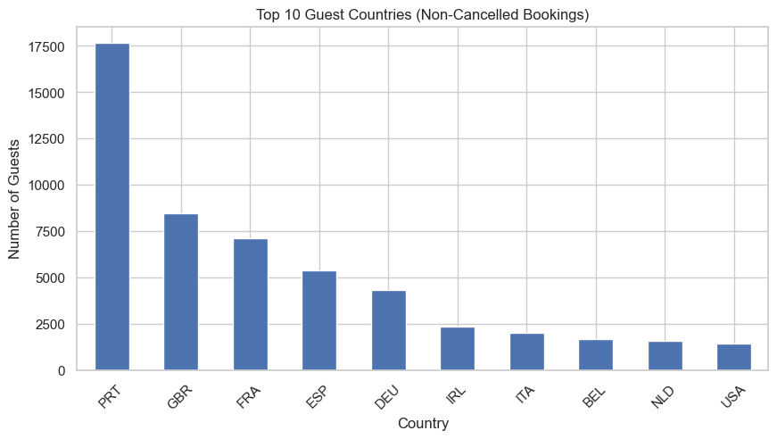

```python
plt.figure(figsize=(10,5))
top_countries.plot(kind='bar')
plt.title("Top 10 Guest Countries (Non-Cancelled Bookings)")
plt.xlabel("Country")
plt.ylabel("Number of Guests")
plt.xticks(rotation=45)
plt.show()
```

Insight: Most hotel guests come from a small number of countries, indicating that Hotel demand is highly concentrated geographically.

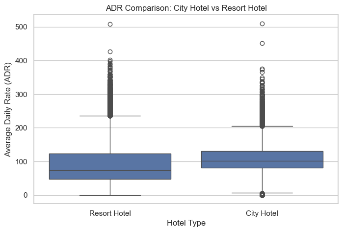

```python
plt.figure(figsize=(8,5))
sns.boxplot(x='hotel', y='adr', data=df_nc)
plt.title("ADR Comparison: City Hotel vs Resort Hotel")
plt.xlabel("Hotel Type")
plt.ylabel("Average Daily Rate (ADR)")
plt.show()
```

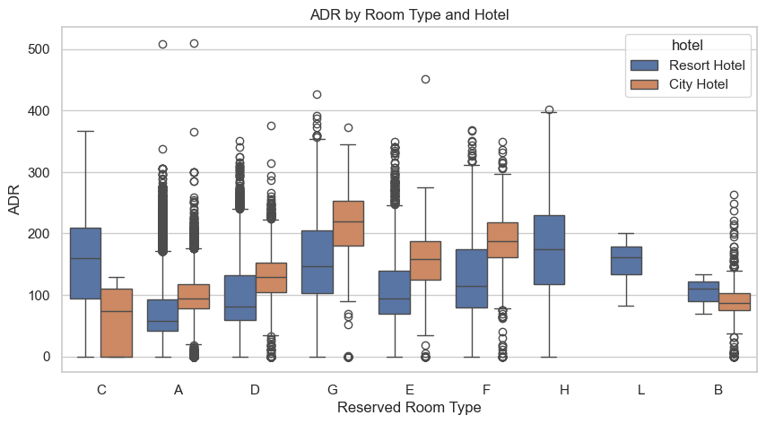

```python
plt.figure(figsize=(10,5))
sns.boxplot(x='reserved_room_type', y='adr', hue='hotel', data=df_nc)
plt.title("ADR by Room Type and Hotel")
plt.xlabel("Reserved Room Type")
plt.ylabel("ADR")
plt.show()
```

```python
# Correct calendar order for months
month_order = [
    'January','February','March','April','May','June',
    'July','August','September','October','November','December'
]

df_nc = df_nc.copy()

df_nc.loc[:, 'arrival_date_month'] = pd.Categorical(
    df_nc['arrival_date_month'],
    categories=month_order,
    ordered=True
)
```

```python
monthly_adr = (
    df_nc
    .groupby(['arrival_date_month', 'hotel'], observed=True)['adr']
    .mean()
    .reset_index()
)
monthly_adr.head()
```

|  | arrival_date_month | hotel | adr |
| --- | --- | --- | --- |
| 0 | January | City Hotel | 83.180097 |
| 1 | January | Resort Hotel | 48.542066 |
| 2 | February | City Hotel | 87.843338 |
| 3 | February | Resort Hotel | 53.624311 |
| 4 | March | City Hotel | 90.759820 |

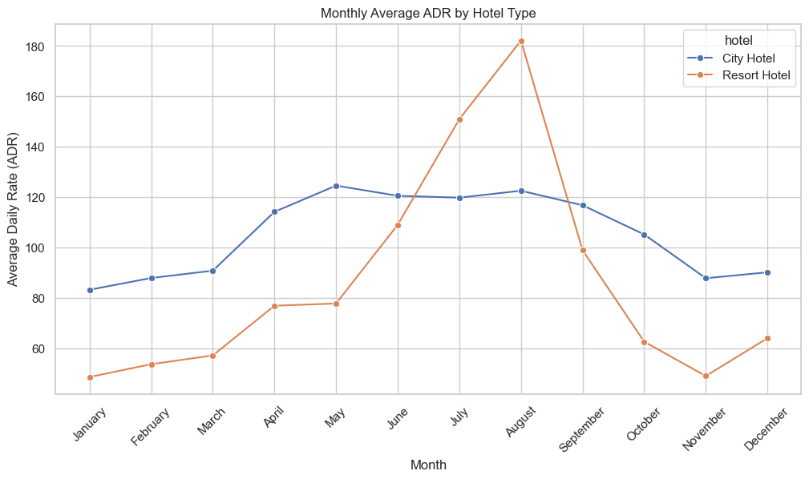

```python
plt.figure(figsize=(12,6))
sns.lineplot(
    data=monthly_adr,
    x='arrival_date_month',
    y='adr',
    hue='hotel',
    marker='o'
)
plt.title("Monthly Average ADR by Hotel Type")
plt.xlabel("Month")
plt.ylabel("Average Daily Rate (ADR)")
plt.xticks(rotation=45)
plt.show()
```

Insight: ADR shows strong seasonality. Resort Hotels experience peak prices during summer months, while City Hotels show more stable pricing throughout the year.

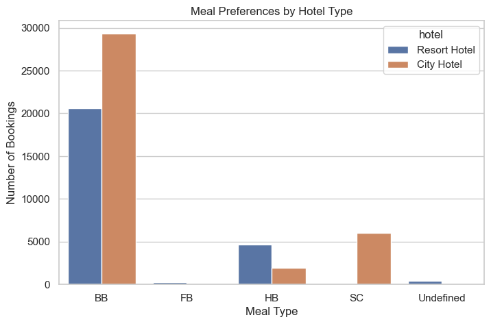

```python
plt.figure(figsize=(8,5))
sns.countplot(x='meal', hue='hotel', data=df_nc)
plt.title("Meal Preferences by Hotel Type")
plt.xlabel("Meal Type")
plt.ylabel("Number of Bookings")
plt.show()
```

Insight: Meal preferences differ between City and Resort hotels. Bed & Breakfast (BB) is the most common meal type, while Resort Hotels show relatively higher preference for full board and half board options.

```python
request_cancel = pd.crosstab(
    df['total_of_special_requests'],
    df['is_canceled']
)

request_cancel
```

| is_canceled total_of_special_requests | 0 | 1 |
| --- | --- | --- |
| 0 | 29319 | 14574 |
| 1 | 22514 | 6503 |
| 2 | 9297 | 2515 |
| 3 | 1920 | 397 |
| 4 | 286 | 34 |
| 5 | 34 | 2 |

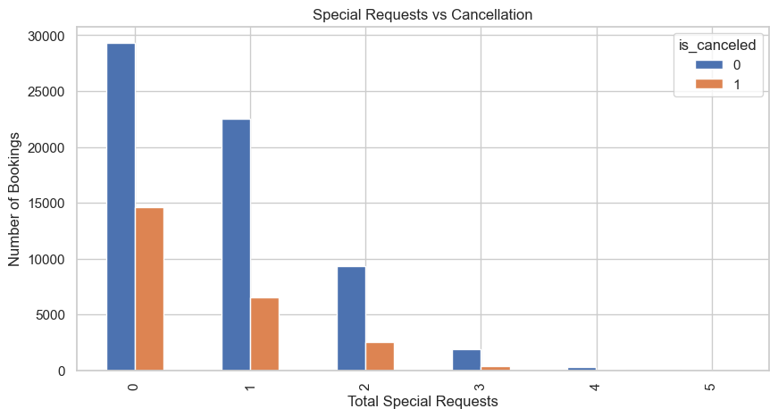

```python
request_cancel.plot(kind='bar', figsize=(10,5))
plt.title("Special Requests vs Cancellation")
plt.xlabel("Total Special Requests")
plt.ylabel("Number of Bookings")
plt.show()
```

Insight: Bookings with a higher number of special requests are less likely to be cancelled, indicating stronger guest commitment.

```python
busy_months = (
    df_nc
    .groupby(['arrival_date_month', 'hotel'], observed=True)
    .size()
    .reset_index(name='booking_count')
)

busy_months.head()
```

|  | arrival_date_month | hotel | booking_count |
| --- | --- | --- | --- |
| 0 | January | City Hotel | 1966 |
| 1 | January | Resort Hotel | 1689 |
| 2 | February | City Hotel | 2630 |
| 3 | February | Resort Hotel | 2053 |
| 4 | March | City Hotel | 3491 |

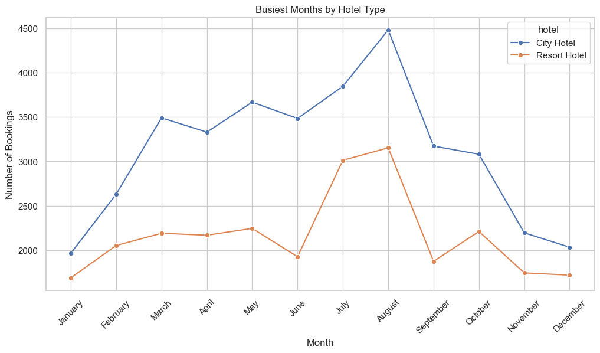

```python
plt.figure(figsize=(12,6))
sns.lineplot(
    data=busy_months,
    x='arrival_date_month',
    y='booking_count',
    hue='hotel',
    marker='o'
)
plt.title("Busiest Months by Hotel Type")
plt.xlabel("Month")
plt.ylabel("Number of Bookings")
plt.xticks(rotation=45)
plt.show()
```

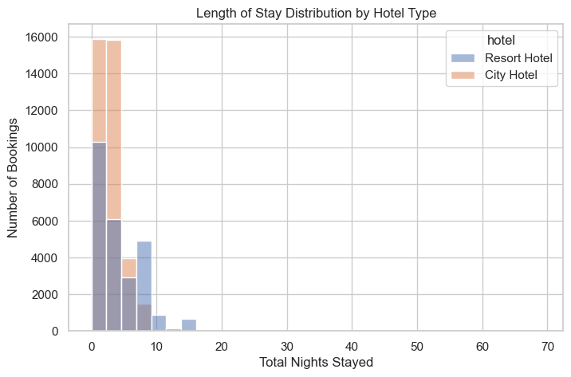

```python
plt.figure(figsize=(8,5))
sns.histplot(
    data=df_nc,
    x='total_nights',
    hue='hotel',
    bins=30,
    kde=False
)
plt.title("Length of Stay Distribution by Hotel Type")
plt.xlabel("Total Nights Stayed")
plt.ylabel("Number of Bookings")
plt.show()
```

Insight: Guests staying at Resort Hotels generally have longer stays compared to City Hotel guests, which aligns with leisure travel behavior.

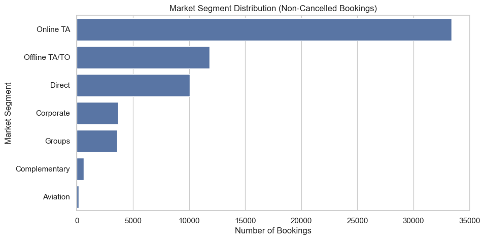

```python
plt.figure(figsize=(10,5))
sns.countplot(
    y='market_segment',
    data=df_nc,
    order=df_nc['market_segment'].value_counts().index
)
plt.title("Market Segment Distribution (Non-Cancelled Bookings)")
plt.xlabel("Number of Bookings")
plt.ylabel("Market Segment")
plt.show()
```

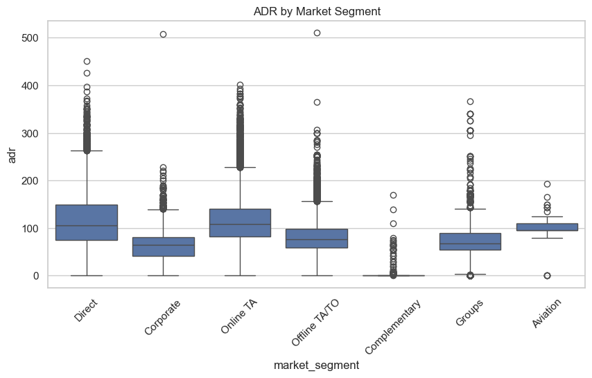

```python
plt.figure(figsize=(10,5))
sns.boxplot(
    x='market_segment',
    y='adr',
    data=df_nc
)
plt.title("ADR by Market Segment")
plt.xticks(rotation=45)
plt.show()
```

```python
cancel_rate = df.groupby('hotel')['is_canceled'].mean() * 100
cancel_rate
```

```
hotel
City Hotel      30.038557
Resort Hotel    23.481615
Name: is_canceled, dtype: float64
```

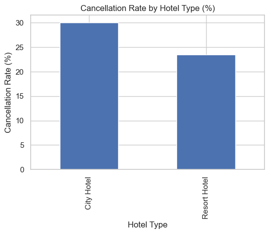

```python
plt.figure(figsize=(6,4))
cancel_rate.plot(kind='bar')
plt.title("Cancellation Rate by Hotel Type (%)")
plt.ylabel("Cancellation Rate (%)")
plt.xlabel("Hotel Type")
plt.show()
```

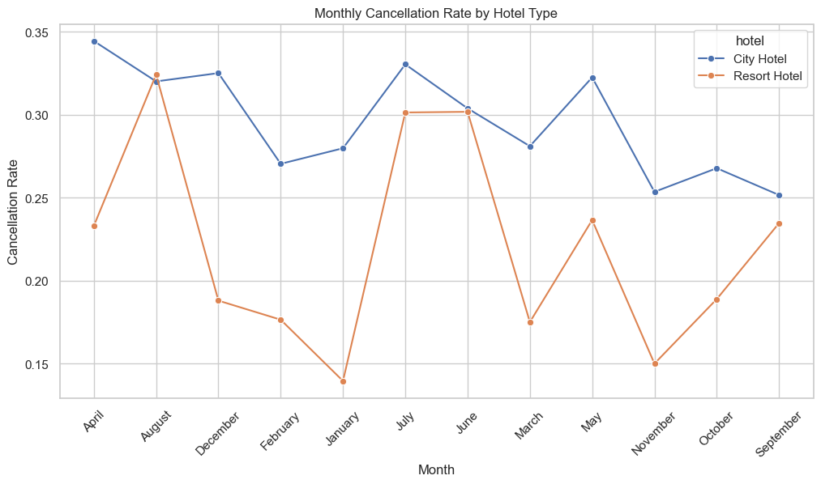

```python
cancel_by_month = (
    df
    .groupby(['arrival_date_month', 'hotel'], observed=True)['is_canceled']
    .mean()
    .reset_index()
)

plt.figure(figsize=(12,6))
sns.lineplot(
    data=cancel_by_month,
    x='arrival_date_month',
    y='is_canceled',
    hue='hotel',
    marker='o'
)
plt.title("Monthly Cancellation Rate by Hotel Type")
plt.xlabel("Month")
plt.ylabel("Cancellation Rate")
plt.xticks(rotation=45)
plt.show()
```

Insight: City Hotels have a higher cancellation rate compared to Resort Hotels. Cancellations also vary by season, with certain peak months experiencing significantly higher cancellation volumes.